# Superstore Dataset

```python
%%HTML
<h1 style= "text-align:center;padding:30px;border-radius:30px;background:black;font-size:bold;color:green;">
Superstore Dataset
</h1>
```

Superstore Dataset

```python
import kagglehub

# Download latest version
path = kagglehub.dataset_download("vivek468/superstore-dataset-final")

print("Path to dataset files:", path)
```

```
Path to dataset files: C:\Users\USER\.cache\kagglehub\datasets\vivek468\superstore-dataset-final\versions\1
```

```python
import os
print(os.listdir(path))
```

```
['Sample - Superstore.csv']
```

```python
import pandas as pd
import os

df = pd.read_csv(
    os.path.join(path, "Sample - Superstore.csv"),
    encoding="cp1252"
)

df.head(10)
```

|  | Row ID | Order ID | Order Date | Ship Date | Ship Mode | Customer ID | Customer Name | Segment | Country | City | ... | Postal Code | Region | Product ID | Category | Sub-Category | Product Name | Sales | Quantity | Discount | Profit |
| --- | --- | --- | --- | --- | --- | --- | --- | --- | --- | --- | --- | --- | --- | --- | --- | --- | --- | --- | --- | --- | --- |
| 0 | 1 | CA-2016-152156 | 11/8/2016 | 11/11/2016 | Second Class | CG-12520 | Claire Gute | Consumer | United States | Henderson | ... | 42420 | South | FUR-BO-10001798 | Furniture | Bookcases | Bush Somerset Collection Bookcase | 261.9600 | 2 | 0.00 | 41.9136 |
| 1 | 2 | CA-2016-152156 | 11/8/2016 | 11/11/2016 | Second Class | CG-12520 | Claire Gute | Consumer | United States | Henderson | ... | 42420 | South | FUR-CH-10000454 | Furniture | Chairs | Hon Deluxe Fabric Upholstered Stacking Chairs,... | 731.9400 | 3 | 0.00 | 219.5820 |
| 2 | 3 | CA-2016-138688 | 6/12/2016 | 6/16/2016 | Second Class | DV-13045 | Darrin Van Huff | Corporate | United States | Los Angeles | ... | 90036 | West | OFF-LA-10000240 | Office Supplies | Labels | Self-Adhesive Address Labels for Typewriters b... | 14.6200 | 2 | 0.00 | 6.8714 |
| 3 | 4 | US-2015-108966 | 10/11/2015 | 10/18/2015 | Standard Class | SO-20335 | Sean O'Donnell | Consumer | United States | Fort Lauderdale | ... | 33311 | South | FUR-TA-10000577 | Furniture | Tables | Bretford CR4500 Series Slim Rectangular Table | 957.5775 | 5 | 0.45 | -383.0310 |
| 4 | 5 | US-2015-108966 | 10/11/2015 | 10/18/2015 | Standard Class | SO-20335 | Sean O'Donnell | Consumer | United States | Fort Lauderdale | ... | 33311 | South | OFF-ST-10000760 | Office Supplies | Storage | Eldon Fold 'N Roll Cart System | 22.3680 | 2 | 0.20 | 2.5164 |
| 5 | 6 | CA-2014-115812 | 6/9/2014 | 6/14/2014 | Standard Class | BH-11710 | Brosina Hoffman | Consumer | United States | Los Angeles | ... | 90032 | West | FUR-FU-10001487 | Furniture | Furnishings | Eldon Expressions Wood and Plastic Desk Access... | 48.8600 | 7 | 0.00 | 14.1694 |
| 6 | 7 | CA-2014-115812 | 6/9/2014 | 6/14/2014 | Standard Class | BH-11710 | Brosina Hoffman | Consumer | United States | Los Angeles | ... | 90032 | West | OFF-AR-10002833 | Office Supplies | Art | Newell 322 | 7.2800 | 4 | 0.00 | 1.9656 |
| 7 | 8 | CA-2014-115812 | 6/9/2014 | 6/14/2014 | Standard Class | BH-11710 | Brosina Hoffman | Consumer | United States | Los Angeles | ... | 90032 | West | TEC-PH-10002275 | Technology | Phones | Mitel 5320 IP Phone VoIP phone | 907.1520 | 6 | 0.20 | 90.7152 |
| 8 | 9 | CA-2014-115812 | 6/9/2014 | 6/14/2014 | Standard Class | BH-11710 | Brosina Hoffman | Consumer | United States | Los Angeles | ... | 90032 | West | OFF-BI-10003910 | Office Supplies | Binders | DXL Angle-View Binders with Locking Rings by S... | 18.5040 | 3 | 0.20 | 5.7825 |
| 9 | 10 | CA-2014-115812 | 6/9/2014 | 6/14/2014 | Standard Class | BH-11710 | Brosina Hoffman | Consumer | United States | Los Angeles | ... | 90032 | West | OFF-AP-10002892 | Office Supplies | Appliances | Belkin F5C206VTEL 6 Outlet Surge | 114.9000 | 5 | 0.00 | 34.4700 |

10 rows × 21 columns

**CHECKING DATASET SHAPE**

```python
df.shape
```

```
(9994, 21)
```

**CHECKING COLUMNS**

```python
df.columns
```

```
Index(['Row ID', 'Order ID', 'Order Date', 'Ship Date', 'Ship Mode',
       'Customer ID', 'Customer Name', 'Segment', 'Country', 'City', 'State',
       'Postal Code', 'Region', 'Product ID', 'Category', 'Sub-Category',
       'Product Name', 'Sales', 'Quantity', 'Discount', 'Profit'],
      dtype='object')
```

**CHECKING NULL**

```python
df.isnull().sum()
```

```
Row ID           0
Order ID         0
Order Date       0
Ship Date        0
Ship Mode        0
Customer ID      0
Customer Name    0
Segment          0
Country          0
City             0
State            0
Postal Code      0
Region           0
Product ID       0
Category         0
Sub-Category     0
Product Name     0
Sales            0
Quantity         0
Discount         0
Profit           0
dtype: int64
```

**CHECKING DUPLICATES**

```python
df.duplicated().sum()
```

```
np.int64(0)
```

**CHECKING D.TYPES**

```python
df.dtypes
```

```
Row ID             int64
Order ID          object
Order Date        object
Ship Date         object
Ship Mode         object
Customer ID       object
Customer Name     object
Segment           object
Country           object
City              object
State             object
Postal Code        int64
Region            object
Product ID        object
Category          object
Sub-Category      object
Product Name      object
Sales            float64
Quantity           int64
Discount         float64
Profit           float64
dtype: object
```

**CONVERTING ORDER DATE AND SHIP DATE INTO DATETIME, CREATING MONTH, DAY, AND PROFIT MARGIN COLUMNS**

```python
df["Order Date"] = pd.to_datetime(df["Order Date"])
```

```python
df["Ship Date"] = pd.to_datetime(df["Ship Date"])
```

```python
df["Month_Name"] = df["Order Date"].dt.month_name()
```

```python
df["Day_Name"] = df["Order Date"].dt.day_name()
```

```python
df["Profit Margin"] = (df["Profit"] / df["Sales"] * 100).round(2)
```

**CHECKING DATA CONSISTENCY AND INCONSISTENCY**

```python
df.groupby("Order ID")["Customer ID"].nunique().max()
```

```
1
```

```python
df.groupby("Order ID")["Order Date"].nunique().max()
```

```
1
```

```python
df.groupby("Order ID")["City"].nunique().max()
```

```
1
```

```python
df.groupby("Customer ID")["Customer Name"].nunique().max()
```

```
1
```

```python
df.groupby("Product ID")["Product Name"].nunique().max()
```

```
2
```

```python
df.groupby("Product ID")["Category"].nunique().max()
```

```
1
```

```python
df.groupby("Product ID")["Sub-Category"].nunique().max()
```

```
1
```

```python
inconsistent_products = (
    df.groupby("Product ID")["Product Name"]
      .nunique()
      .loc[lambda x: x > 1]
)

inconsistent_products
```

```
Product ID
FUR-BO-10002213    2
FUR-CH-10001146    2
FUR-FU-10001473    2
FUR-FU-10004017    2
FUR-FU-10004091    2
FUR-FU-10004270    2
FUR-FU-10004848    2
FUR-FU-10004864    2
OFF-AP-10000576    2
OFF-AR-10001149    2
OFF-BI-10002026    2
OFF-BI-10004632    2
OFF-BI-10004654    2
OFF-PA-10000357    2
OFF-PA-10000477    2
OFF-PA-10000659    2
OFF-PA-10001166    2
OFF-PA-10001970    2
OFF-PA-10002195    2
OFF-PA-10002377    2
OFF-PA-10003022    2
OFF-ST-10001228    2
OFF-ST-10004950    2
TEC-AC-10002049    2
TEC-AC-10002550    2
TEC-AC-10003832    2
TEC-MA-10001148    2
TEC-PH-10001530    2
TEC-PH-10001795    2
TEC-PH-10002200    2
TEC-PH-10002310    2
TEC-PH-10004531    2
Name: Product Name, dtype: int64
```

```python
df[df["Product ID"].isin(inconsistent_products.index)][
    ["Product ID", "Product Name", "Category", "Sub-Category"]
].sort_values("Product ID")
```

|  | Product ID | Product Name | Category | Sub-Category |
| --- | --- | --- | --- | --- |
| 5079 | FUR-BO-10002213 | Sauder Forest Hills Library, Woodland Oak Finish | Furniture | Bookcases |
| 2471 | FUR-BO-10002213 | Sauder Forest Hills Library, Woodland Oak Finish | Furniture | Bookcases |
| 9649 | FUR-BO-10002213 | DMI Eclipse Executive Suite Bookcases | Furniture | Bookcases |
| 9583 | FUR-BO-10002213 | DMI Eclipse Executive Suite Bookcases | Furniture | Bookcases |
| 9395 | FUR-BO-10002213 | DMI Eclipse Executive Suite Bookcases | Furniture | Bookcases |
| ... | ... | ... | ... | ... |
| 922 | TEC-PH-10004531 | OtterBox Commuter Series Case - iPhone 5 & 5s | Technology | Phones |
| 8996 | TEC-PH-10004531 | OtterBox Commuter Series Case - iPhone 5 & 5s | Technology | Phones |
| 3065 | TEC-PH-10004531 | OtterBox Commuter Series Case - iPhone 5 & 5s | Technology | Phones |
| 2713 | TEC-PH-10004531 | AT&T CL2909 | Technology | Phones |
| 8970 | TEC-PH-10004531 | AT&T CL2909 | Technology | Phones |

337 rows × 4 columns

**TOTAL SALES, PROFIT, PROFIT MARGIN, CUSTOMERS, AND ORDERS**

```python
total_sales = df["Sales"].sum()

total_profit = df["Profit"].sum()


total_customers = df["Customer ID"].nunique()

total_orders = df["Order ID"].nunique()

profit_margin = float(
    (df["Profit"].sum() / df["Sales"].sum() * 100).round(2)
)

print(profit_margin)
print(total_sales)
print(total_profit)
print(total_customers)
print(total_orders)
```

```
12.47
2297200.8603
286397.0217
793
5009
```

**MOST USED SHIP MODE**

```python
df["Ship Mode"].value_counts().idxmax()
```

```
'Standard Class'
```

**CUSTOMER WITH HIGHEST SALES AND PROFIT**

```python
SALES = df.groupby("Customer Name")["Sales"].sum().nlargest(1)
PROFIT = df.groupby("Customer Name")["Profit"].sum().nlargest(1)

print(SALES)
print(PROFIT)
```

```
Customer Name
Sean Miller    25043.05
Name: Sales, dtype: float64
Customer Name
Tamara Chand    8981.3239
Name: Profit, dtype: float64
```

**SEGMENT WITH HIGHEST SALES AND PROFIT**

```python
SALES = df.groupby("Segment")["Sales"].sum().nlargest(1)
PROFIT = df.groupby("Segment")["Profit"].sum().nlargest(1)

print(SALES)
print(PROFIT)
```

```
Segment
Consumer    1161401.345
Name: Sales, dtype: float64
Segment
Consumer    134119.2092
Name: Profit, dtype: float64
```

**CATEGORY WITH HIGHEST SALES AND PROFIT**

```python
SALES = df.groupby("Category")["Sales"].sum().nlargest(1)
PROFIT = df.groupby("Category")["Profit"].sum().nlargest(1)

print(SALES)
print(PROFIT)
```

```
Category
Technology    836154.033
Name: Sales, dtype: float64
Category
Technology    145454.9481
Name: Profit, dtype: float64
```

**SUB-CATEGORY WITH HIGHEST SALES AND PROFIT**

```python
SALES = df.groupby("Sub-Category")["Sales"].sum().nlargest(1)
PROFIT = df.groupby("Sub-Category")["Profit"].sum().nlargest(1)

print(SALES)
print(PROFIT)
```

```
Sub-Category
Phones    330007.054
Name: Sales, dtype: float64
Sub-Category
Copiers    55617.8249
Name: Profit, dtype: float64
```

**PRODUCT WITH HIGHEST SALES AND PROFIT**

```python
SALES = df.groupby("Product Name")["Sales"].sum().nlargest(1)
PROFIT = df.groupby("Product Name")["Profit"].sum().nlargest(1)

print(SALES)
print(PROFIT)
```

```
Product Name
Canon imageCLASS 2200 Advanced Copier    61599.824
Name: Sales, dtype: float64
Product Name
Canon imageCLASS 2200 Advanced Copier    25199.928
Name: Profit, dtype: float64
```

**MONTH WITH HIGHEST SALES AND PROFIT**

```python
SALES = df.groupby("Month_Name")["Sales"].sum().nlargest(1)
PROFIT = df.groupby("Month_Name")["Profit"].sum().nlargest(1)

print(SALES)
print(PROFIT)
```

```
Month_Name
November    352461.071
Name: Sales, dtype: float64
Month_Name
December    43369.1919
Name: Profit, dtype: float64
```

**DAY WITH HIGHEST SALES AND PROFIT**

```python
SALES = df.groupby("Day_Name")["Sales"].sum().nlargest(1)
PROFIT = df.groupby("Day_Name")["Profit"].sum().nlargest(1)

print(SALES)
print(PROFIT)
```

```
Day_Name
Monday    428937.8157
Name: Sales, dtype: float64
Day_Name
Sunday    57129.512
Name: Profit, dtype: float64
```

**CITY WITH HIGHEST SALES AND PROFIT**

```python
SALES = df.groupby("City")["Sales"].sum().nlargest(1)
PROFIT = df.groupby("City")["Profit"].sum().nlargest(1)

print(SALES)
print(PROFIT)
```

```
City
New York City    256368.161
Name: Sales, dtype: float64
City
New York City    62036.9837
Name: Profit, dtype: float64
```

**STATE WITH HIGHEST SALES AND PROFIT**

```python
SALES = df.groupby("State")["Sales"].sum().nlargest(1)
PROFIT = df.groupby("State")["Profit"].sum().nlargest(1)

print(SALES)
print(PROFIT)
```

```
State
California    457687.6315
Name: Sales, dtype: float64
State
California    76381.3871
Name: Profit, dtype: float64
```

**REGION WITH HIGHEST SALES AND PROFIT**

```python
SALES = df.groupby("Region")["Sales"].sum().nlargest(1)
PROFIT = df.groupby("Region")["Profit"].sum().nlargest(1)

print(SALES)
print(PROFIT)
```

```
Region
West    725457.8245
Name: Sales, dtype: float64
Region
West    108418.4489
Name: Profit, dtype: float64
```

```python
import plotly.express as px
import matplotlib.pyplot as plt
import plotly.graph_objects as go
from plotly.subplots import make_subplots
```

**MONTHLY SALES TREND**

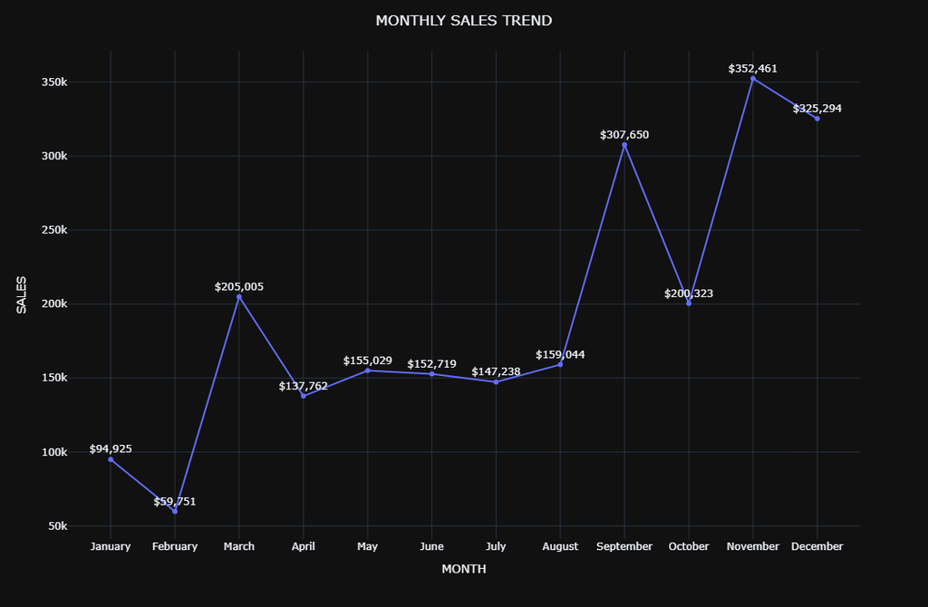

```python
month_order = ["January", "February", "March", "April", "May", "June","July", "August", "September", "October", "November", "December"]

fig = px.line(df.groupby("Month_Name", as_index=False)["Sales"].sum()
.assign(Month_Name=lambda x: pd.Categorical(x["Month_Name"], categories=month_order, ordered=True)).sort_values("Month_Name"),
x="Month_Name",y="Sales",markers=True,text="Sales")

fig.update_traces(texttemplate="$%{text:,.0f}",textposition="top center",cliponaxis=False)

fig.update_layout(title="MONTHLY SALES TREND",title_x=0.5,xaxis_title="MONTH",yaxis_title="SALES",height=700,width=1100,template="plotly_dark")
```

**MONTHLY PROFIT TREND**

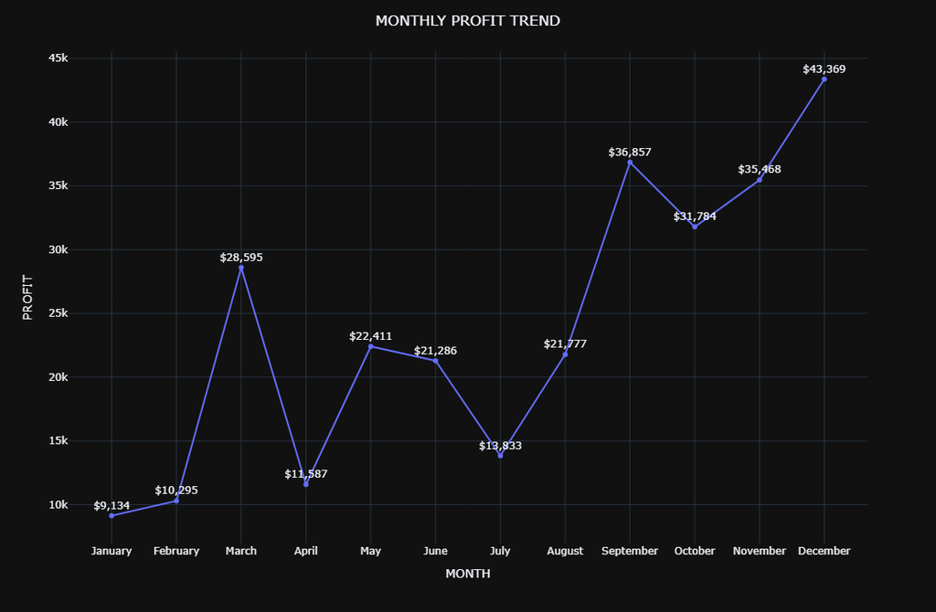

```python
month_order = ["January", "February", "March", "April", "May", "June","July", "August", "September", "October", "November", "December"]

fig = px.line(df.groupby("Month_Name", as_index=False)["Profit"].sum()
.assign(Month_Name=lambda x: pd.Categorical(x["Month_Name"], categories=month_order, ordered=True)).sort_values("Month_Name"),
x="Month_Name",y="Profit",markers=True,text="Profit")

fig.update_traces(texttemplate="$%{text:,.0f}",textposition="top center",cliponaxis=False)

fig.update_layout(title="MONTHLY PROFIT TREND",title_x=0.5,xaxis_title="MONTH",yaxis_title="PROFIT",height=700,width=1100,template="plotly_dark")
```

**DAILY SALES TREND**

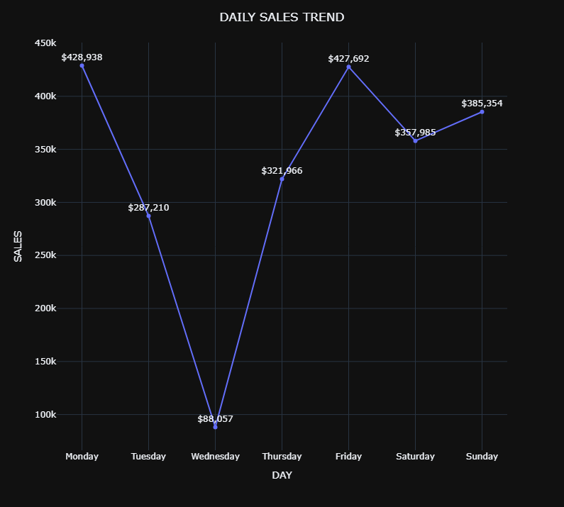

```python
day_order = ["Monday", "Tuesday", "Wednesday", "Thursday", "Friday", "Saturday", "Sunday"]

fig = px.line(df.groupby("Day_Name", as_index=False)["Sales"].sum()
.assign(Day_Name=lambda x: pd.Categorical(x["Day_Name"], categories=day_order, ordered=True)).sort_values("Day_Name"),
x="Day_Name", y="Sales", markers=True, text="Sales")

fig.update_traces(texttemplate="$%{text:,.0f}", textposition="top center", cliponaxis=False)

fig.update_layout(title="DAILY SALES TREND", title_x=0.5, xaxis_title="DAY", yaxis_title="SALES", height=700, width=1100, template="plotly_dark")
```

**DAILY PROFIT TREND**

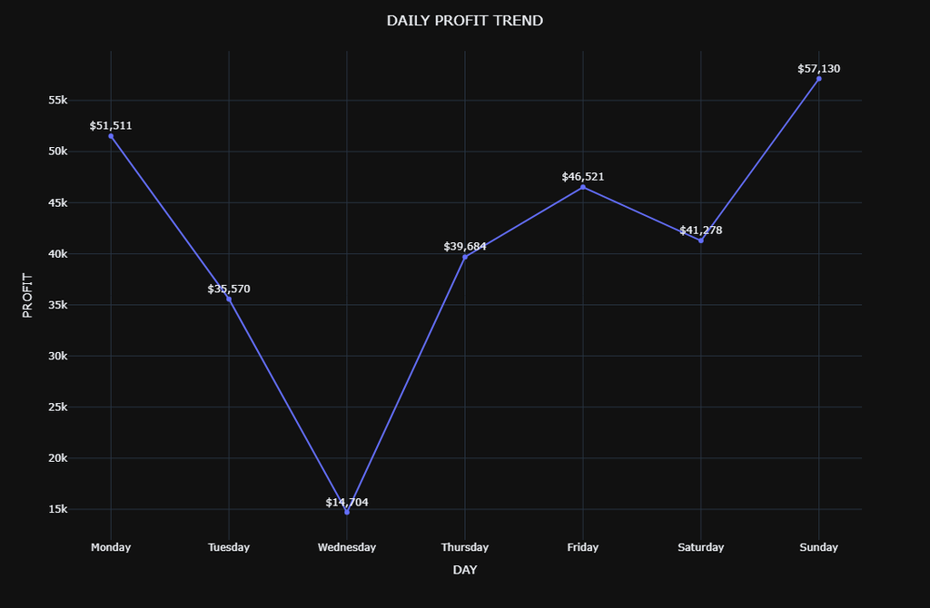

```python
day_order = ["Monday", "Tuesday", "Wednesday", "Thursday", "Friday", "Saturday", "Sunday"]

fig = px.line(df.groupby("Day_Name", as_index=False)["Profit"].sum()
.assign(Day_Name=lambda x: pd.Categorical(x["Day_Name"], categories=day_order, ordered=True)).sort_values("Day_Name"),
x="Day_Name", y="Profit", markers=True, text="Profit")

fig.update_traces(texttemplate="$%{text:,.0f}", textposition="top center", cliponaxis=False)

fig.update_layout(title="DAILY PROFIT TREND", title_x=0.5, xaxis_title="DAY", yaxis_title="PROFIT", height=700, width=1100, template="plotly_dark")
```

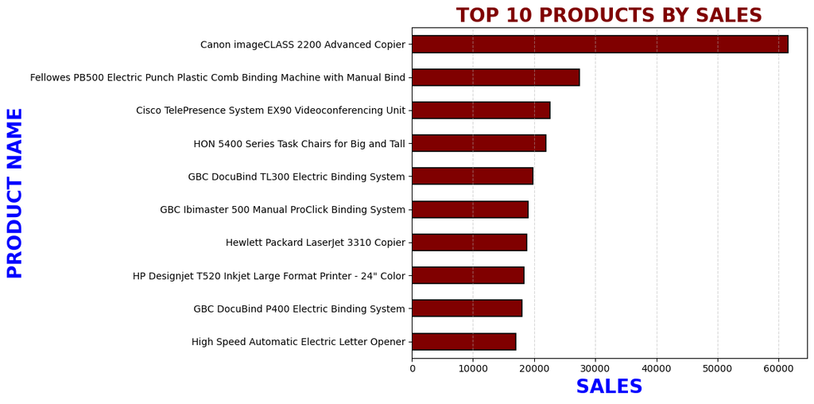

```python
plt.figure(figsize=(12, 6))

df.groupby("Product Name")["Sales"].sum().sort_values(ascending=True).tail(10).plot.barh(
    color="maroon",
    edgecolor="black",
    linewidth=1.2
)

plt.title("TOP 10 PRODUCTS BY SALES", color="maroon", fontsize=20, fontweight="bold")
plt.xlabel("SALES", color="blue", fontsize=20, fontweight="bold")
plt.ylabel("PRODUCT NAME", color="blue", fontsize=20, fontweight="bold")

plt.ticklabel_format(style="plain", axis="x")
plt.grid(axis="x", linestyle="--", alpha=0.5)

plt.tight_layout()
plt.show()
```

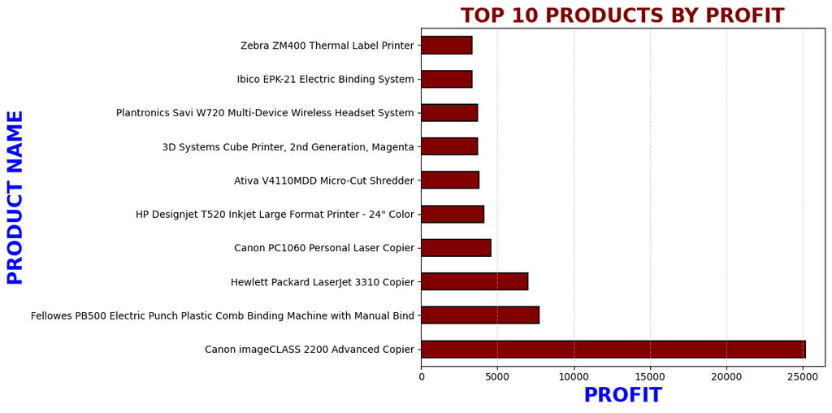

```python
plt.figure(figsize=(12, 6))

df.groupby("Product Name")["Profit"].sum().sort_values(ascending=False).head(10).plot.barh(
    color="maroon",
    edgecolor="black",
    linewidth=1.2
)

plt.title("TOP 10 PRODUCTS BY PROFIT", color="maroon", fontsize=20, fontweight="bold")
plt.xlabel("PROFIT", color="blue", fontsize=20, fontweight="bold")
plt.ylabel("PRODUCT NAME", color="blue", fontsize=20, fontweight="bold")

plt.ticklabel_format(style="plain", axis="x")
plt.grid(axis="x", linestyle="--", alpha=0.5)

plt.tight_layout()
plt.show()
```

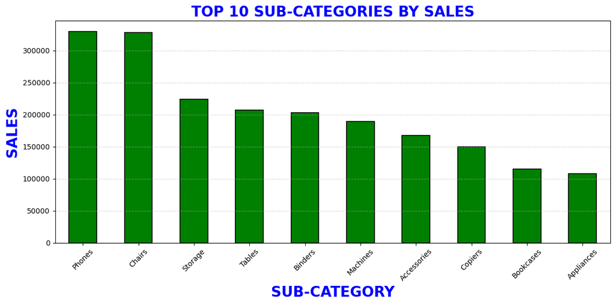

```python
plt.figure(figsize=(12, 6))

df.groupby("Sub-Category")["Sales"].sum().sort_values(ascending=False).head(10).plot.bar(
    color="green", edgecolor="black", linewidth=1.2
)

plt.title("TOP 10 SUB-CATEGORIES BY SALES", color="blue", fontsize=20, fontweight="bold")
plt.xlabel("SUB-CATEGORY", color="blue", fontsize=20, fontweight="bold")
plt.ylabel("SALES", color="blue", fontsize=20, fontweight="bold")

plt.ticklabel_format(style="plain", axis="y")
plt.xticks(rotation=45)
plt.grid(axis="y", linestyle="--", alpha=0.5)

plt.tight_layout()
plt.show()
```

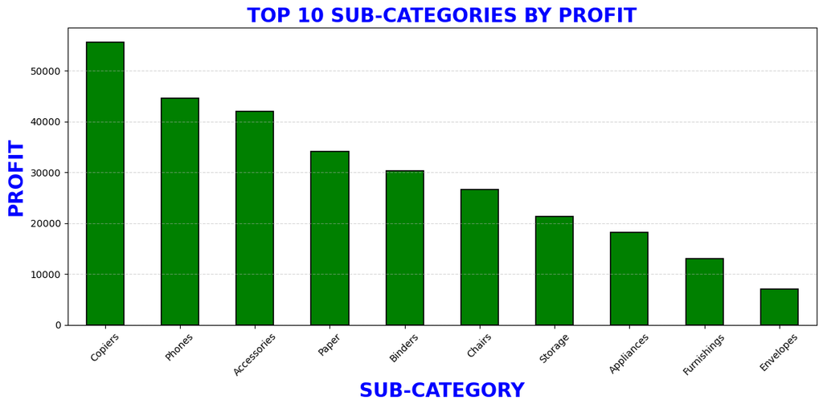

```python
plt.figure(figsize=(12, 6))

df.groupby("Sub-Category")["Profit"].sum().sort_values(ascending=False).head(10).plot.bar(
    color="green", edgecolor="black", linewidth=1.2
)

plt.title("TOP 10 SUB-CATEGORIES BY PROFIT", color="blue", fontsize=20, fontweight="bold")
plt.xlabel("SUB-CATEGORY", color="blue", fontsize=20, fontweight="bold")
plt.ylabel("PROFIT", color="blue", fontsize=20, fontweight="bold")

plt.ticklabel_format(style="plain", axis="y")
plt.xticks(rotation=45)
plt.grid(axis="y", linestyle="--", alpha=0.5)

plt.tight_layout()
plt.show()
```

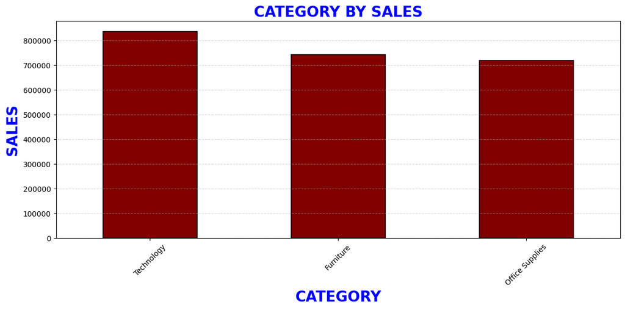

```python
plt.figure(figsize=(12, 6))

df.groupby("Category")["Sales"].sum().sort_values(ascending=False).head(10).plot.bar(
    color="maroon", edgecolor="black", linewidth=1.2
)

plt.title("CATEGORY BY SALES", color="blue", fontsize=20, fontweight="bold")
plt.xlabel("CATEGORY", color="blue", fontsize=20, fontweight="bold")
plt.ylabel("SALES", color="blue", fontsize=20, fontweight="bold")

plt.ticklabel_format(style="plain", axis="y")
plt.xticks(rotation=45)
plt.grid(axis="y", linestyle="--", alpha=0.5)

plt.tight_layout()
plt.show()
```

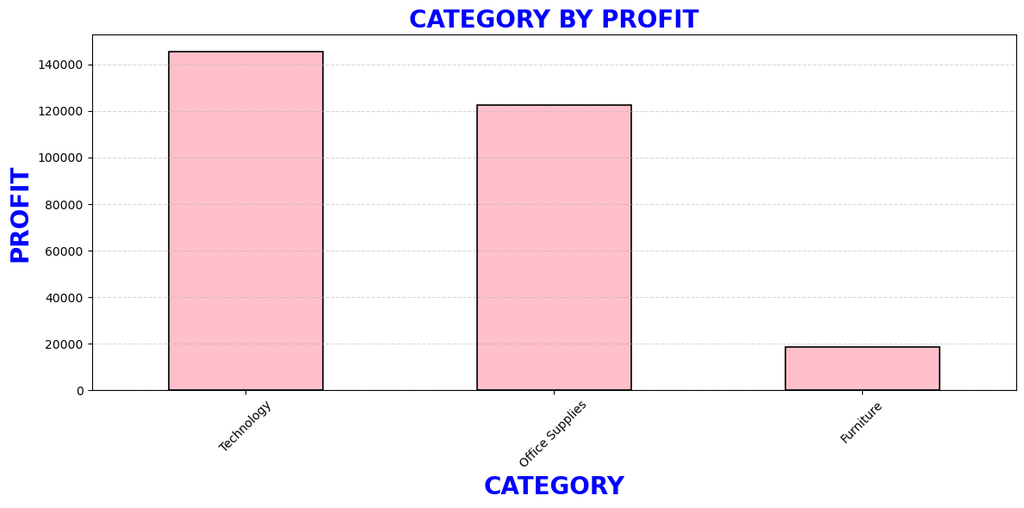

```python
plt.figure(figsize=(12, 6))

df.groupby("Category")["Profit"].sum().sort_values(ascending=False).head(10).plot.bar(
    color="pink", edgecolor="black", linewidth=1.2
)

plt.title("CATEGORY BY PROFIT", color="blue", fontsize=20, fontweight="bold")
plt.xlabel("CATEGORY", color="blue", fontsize=20, fontweight="bold")
plt.ylabel("PROFIT", color="blue", fontsize=20, fontweight="bold")

plt.ticklabel_format(style="plain", axis="y")
plt.xticks(rotation=45)
plt.grid(axis="y", linestyle="--", alpha=0.5)

plt.tight_layout()
plt.show()
```

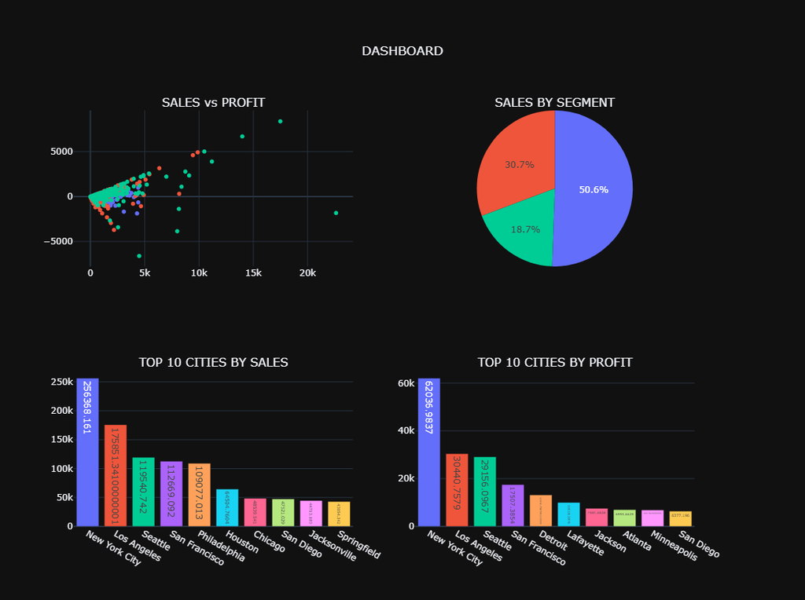

```python
fig=make_subplots(rows=2,cols=2,
specs=[[{"type":"xy"},{"type":"domain"}], [{"type":"xy"}]*2],
subplot_titles=("SALES vs PROFIT","SALES BY SEGMENT","TOP 10 CITIES BY SALES","TOP 10 CITIES BY PROFIT"))
def add(f, r, c):
    [fig.add_trace(tr, row=r, col=c) for tr in f.data]
add(px.scatter(df,x="Sales",y="Profit",color="Category",hover_name="Customer Name"),1,1)
add(px.pie(df.groupby("Segment", as_index=False)["Sales"].sum().sort_values("Sales", ascending=False), names="Segment", values="Sales", color="Segment"),1,2)
add(px.bar(df.groupby("City", as_index=False)["Sales"].sum().sort_values("Sales", ascending=False).head(10), x="City", y="Sales", text="Sales", color="City"),2,1)
add(px.bar(df.groupby("City", as_index=False)["Profit"].sum().sort_values("Profit", ascending=False).head(10), x="City", y="Profit", text="Profit", color="City"),2,2)
fig.update_layout(title={"text":"DASHBOARD", "x":0.5},height=800, width=1100, template="plotly_dark", showlegend=False, margin=dict(l=100,r=150,t=150,b=100))
```

```python
from IPython.display import HTML, display

TOTAL_SALES = df["Sales"].sum()
TOTAL_PROFIT = df["Profit"].sum()
PROFIT_MARGIN = (TOTAL_PROFIT / TOTAL_SALES) * 100
TOTAL_CUSTOMERS = df["Customer Name"].nunique()
TOTAL_ORDERS = df["Order ID"].nunique()

html = f"""
<style>
body{{background:black;font-family:Arial,sans-serif;}}
.container{{display:flex;gap:30px;padding:30px;flex-wrap:wrap;justify-content:center;background:black;}}
.card{{width:250px;padding:30px;text-align:center;border-radius:30px;color:pink;background:linear-gradient(150deg,#1a1a1a,#2e2e2e);
box-shadow:4px 4px 10px hotpink;transition:0.5s;}}
.card:hover{{transform:translateY(-10px) scale(1.05);box-shadow:0 20px 40px hotpink;}}
.title{{font-size:25px;letter-spacing:1px;}}
.value{{font-size:40px;font-weight:bold;margin:10px;}}
</style>
<div class="container">
<div class="card">
<h2 class="title">💰 TOTAL SALES</h2>
<h1 class="value">${TOTAL_SALES:,.0f}</h1>
</div>
<div class="card">
<h2 class="title">💵 TOTAL PROFIT</h2>
<h1 class="value">${TOTAL_PROFIT:,.0f}</h1>
</div>
<div class="card">
<h2 class="title">📈 PROFIT MARGIN</h2>
<h1 class="value">{PROFIT_MARGIN:.1f}%</h1>
</div>
<div class="card">
<h2 class="title">👥 TOTAL CUSTOMERS</h2>
<h1 class="value">{TOTAL_CUSTOMERS}</h1>
</div>
<div class="card">
<h2 class="title">🧾 TOTAL ORDERS</h2>
<h1 class="value">{TOTAL_ORDERS}</h1>
</div>
</div>
"""

display(HTML(html))
```

💰 TOTAL SALES

$2,297,201

💵 TOTAL PROFIT

$286,397

📈 PROFIT MARGIN

12.5%

👥 TOTAL CUSTOMERS

793

🧾 TOTAL ORDERS

5009